# Advanced `ggplot2` Homework - Answers

# 1 Homework Info

## 1.1 Learning Objectives

- Practice making plots with ggplot2
- Create your own theme and use it with plots

## 1.2 Background

QikBit is a start-up company producing low cost fitness trackers. Their flagship product, the KwikBit Unit1 (spot the mistake on the patent form) reproduces the functionality of the best-in-class commercial fitness trackers, but is cheap to make. They are currently preparing to pitch to a potential investor and require a selection of charts to include in their presentation and promotional materials.

## 1.3 Data

The data for this assignment is provided in the `CodeClanData` package.

- `qb_revenue_breakdown`
- `qb_monthly_sales`
- `qb_competitors`
- `qb_device_data`

Take a little time before you start to familiarise yourself with the data.

# 2 MVP

## 2.1 Part 1

**Question 1.**  
Take the data in the dataset `qb_revenue_breakdown` and make a stacked bar chart showing the sources of revenue across the two years in the dataset.

**Answer**

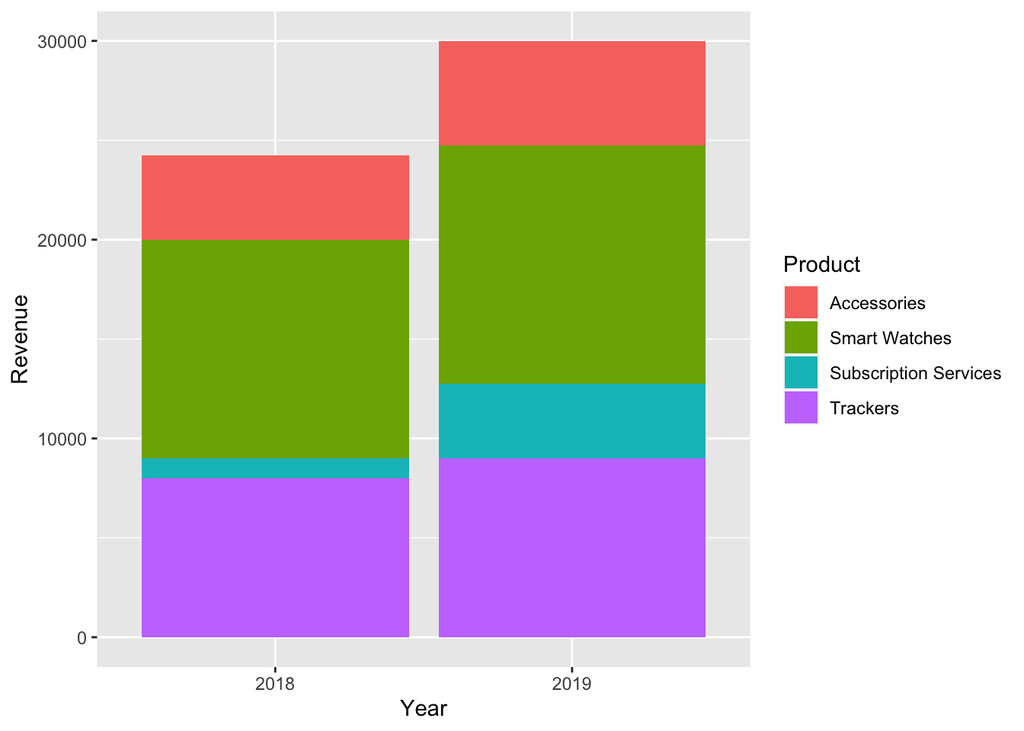

```r
library(ggplot2)
library(CodeClanData)
library(dplyr)

ggplot(qb_revenue_breakdown) +
  aes(x = Year, y = Revenue, fill = Product) +
  geom_col()
```

**Question 2.**  
Make a line chart showing monthly sales of the “flagship product” - the ‘KwikBit Unit 1’ - over the last year. This data is inside `qb_monthly_sales`, but you will need to use `filter()` or `subset()` (base `R)`.

**Answer**

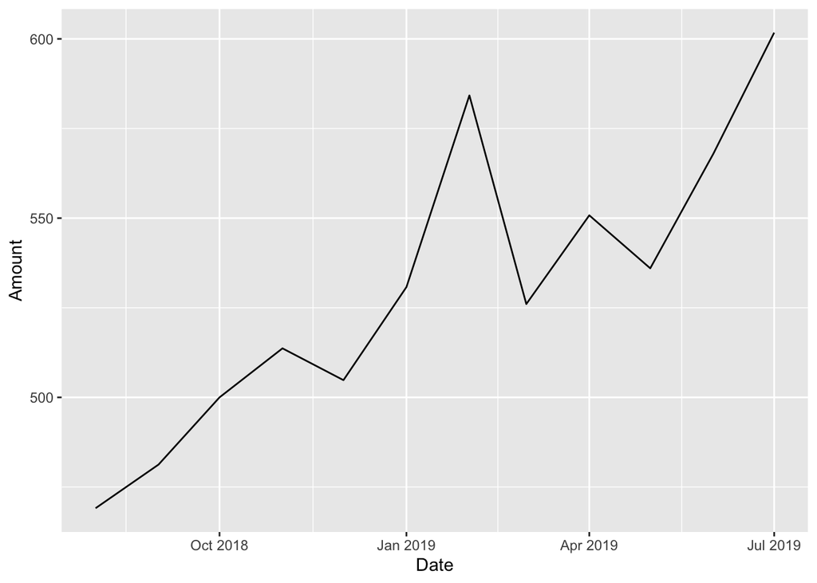

```r
kwikbit_sales <- subset(qb_monthly_sales, Cashflow == "Kwikbit Unit 1 Sales")

# or

kwikbit_sales <- qb_monthly_sales %>%
  filter(Cashflow == "Kwikbit Unit 1 Sales")

ggplot(kwikbit_sales) +
  aes(x = Date, y = Amount) +
  geom_line()
```

**Question 3.**  
Make a line chart showing monthly revenue and costs over the last year. This data is also in `qb_monthly_sales`.

**Answer**

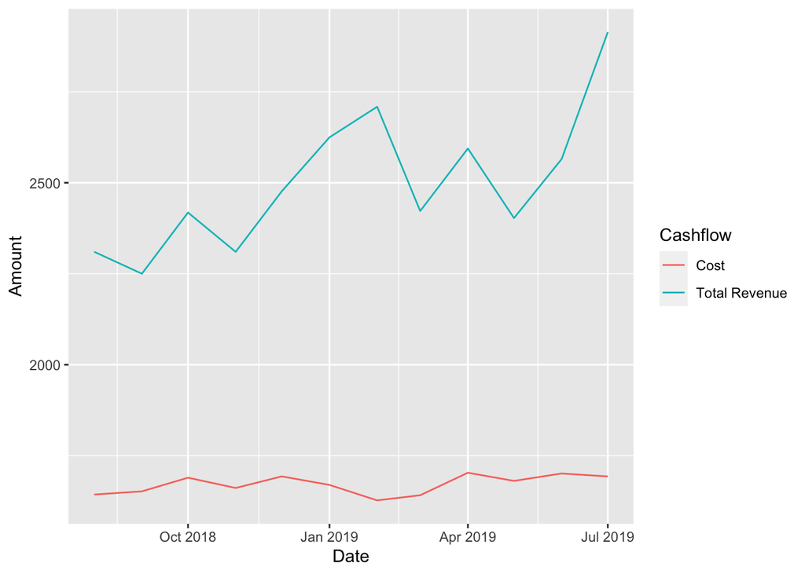

```r
kwikbit_sales <- subset(qb_monthly_sales, Cashflow != "Kwikbit Unit 1 Sales")

# or

revenue_and_costs <- qb_monthly_sales %>%
  filter(Cashflow != "Kwikbit Unit 1 Sales")

ggplot(revenue_and_costs) +
  aes(x = Date, y = Amount, colour = Cashflow) +
  geom_line()
```

**Question 4.**  
Show annual sales of personal fitness trackers over the last 5 years broken down by company as a ribbon plot (use `geom_area`). This data is in `qb_competitors`.

**Answer**

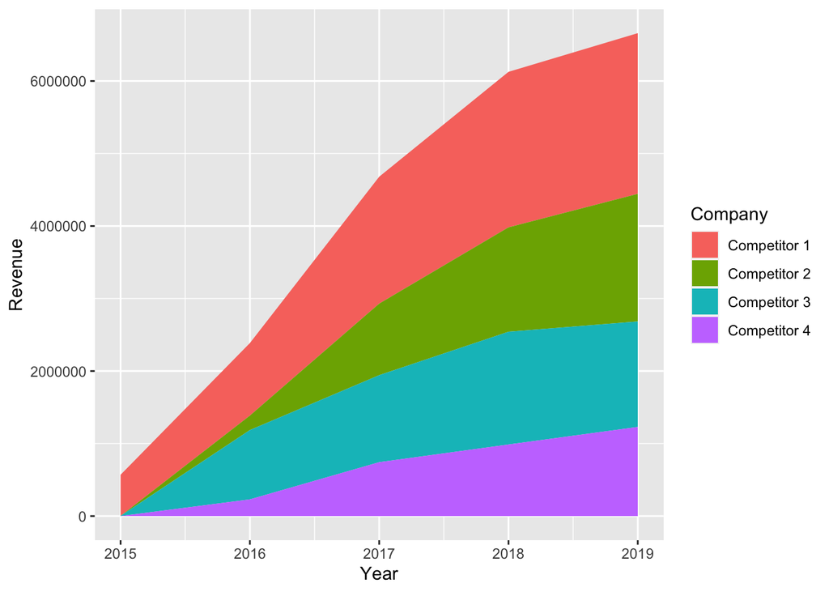

```r
options(scipen = 999)
ggplot(qb_competitors) +
  aes(x = Year, y = Revenue, fill = Company) +
  geom_area()
```

While the visualisation above works, a dodged bar plot is perhaps easier to understand:

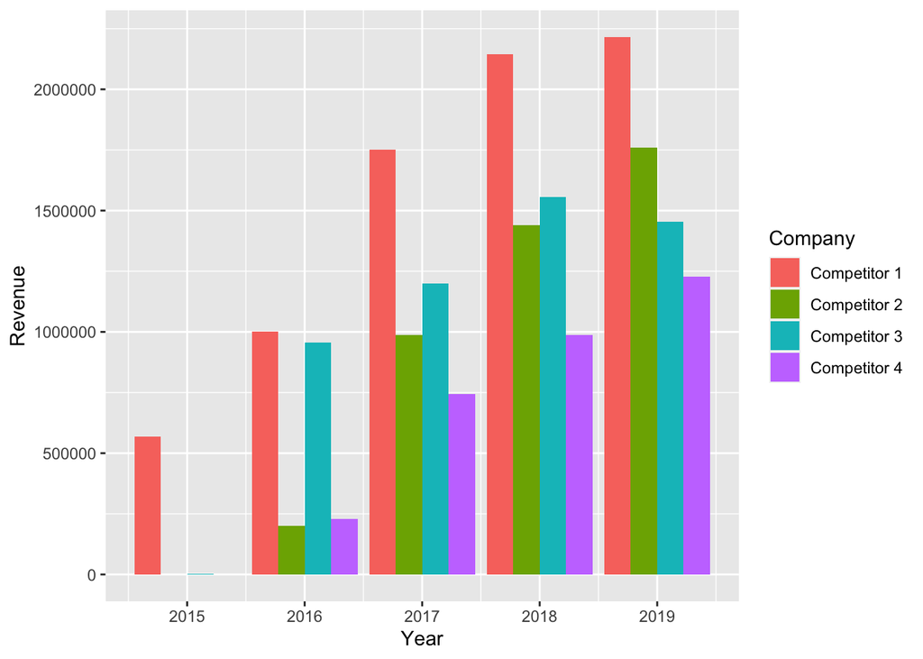

```r
ggplot(qb_competitors) +
  aes(x = Year, y = Revenue, fill = Company) +
  geom_col(position = "dodge")
```

**Question 5.**  
Now show the sales from the four competitors as a line graph. Include an extra layer that shows the data points used to make the lines.

**Answer**

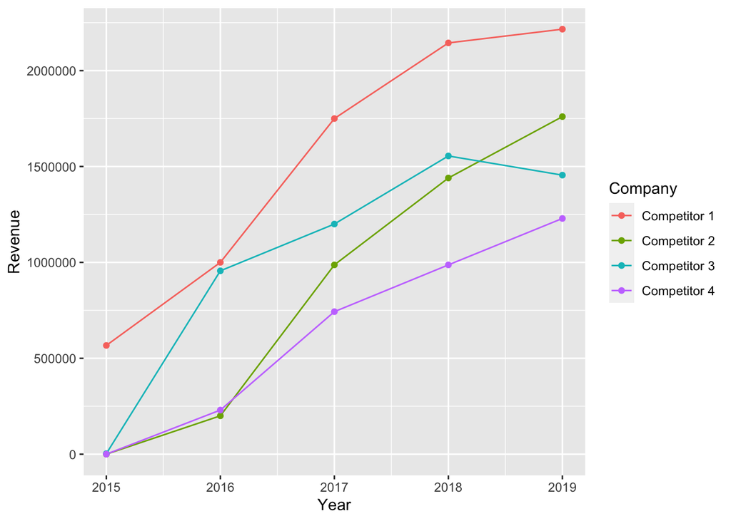

```r
ggplot(qb_competitors) +
  aes(x = Year, y = Revenue, colour = Company) +
  geom_line() +
  geom_point()
```

**Question 6.**  
Now the company wants to compare the number of steps that their device counts vs. their competitors. Make a line graph of the number of steps throughout time, and use faceting to compare between companies and people. The data for this is in `qb_device_data`.

**Answer**

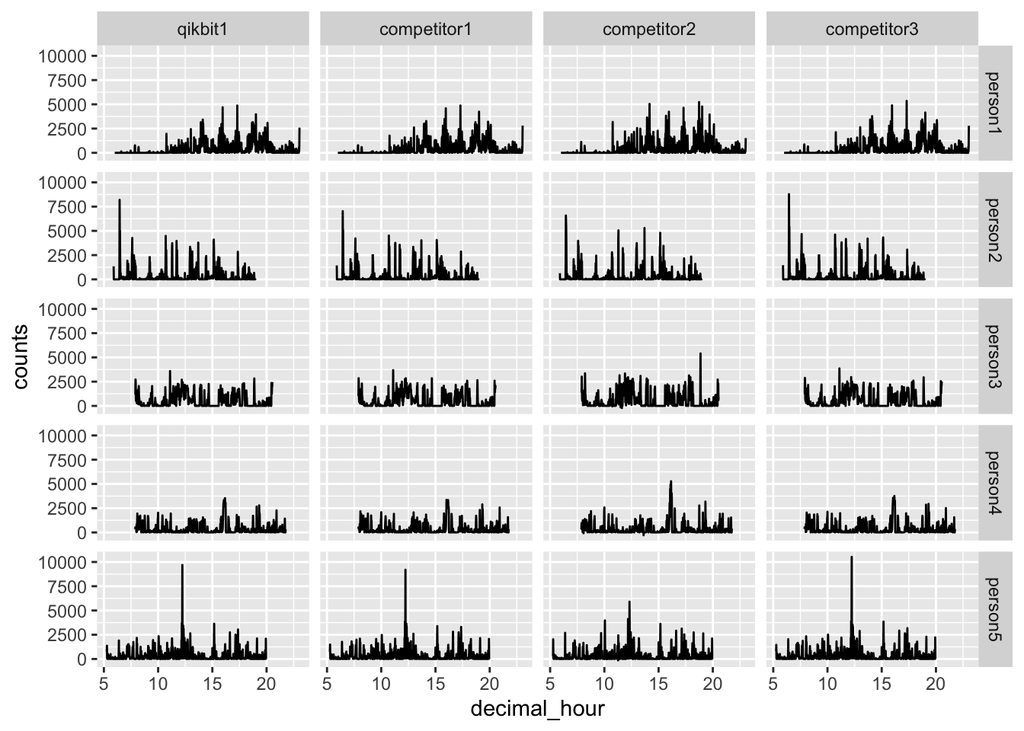

```r
qb_device_data <-
mutate(qb_device_data, decimal_hour = hours + (mins/60))

ggplot(qb_device_data) +
  aes(x = decimal_hour, y = counts) +
  geom_line() +
  facet_grid(id ~ device)
```

## 2.2 Part 2

**Question 1.**  
Take the plots that you produced in part one and now polish them by:

1. Adding appropriate labels
2. Changing the scales and coordinates when appropriate.
3. Applying a unified theme, which is described below:
- Graphs should have white backgrounds, and use colour sparingly.
- There should be faint grid lines.
- Font sizes should be ~12pt although titles should be slightly larger and axis labels can be slightly smaller.
- All plots should use colours from the following company colour scheme.

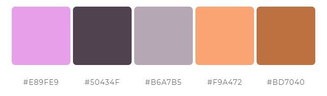

```r
col_scheme <- c("#E89FE9", "#50434F", "#B6A7B5", "#F9A472", "#BD7040")
```

**Answer**

```r
theme_qb <-
  theme(
    text = element_text(size = 12),
    title = element_text(size = 14),
    axis.text = element_text(size = 10),
    panel.background = element_rect(fill = "white"),
    panel.grid = element_line(colour = "grey90", linetype = "dashed")
  )
```

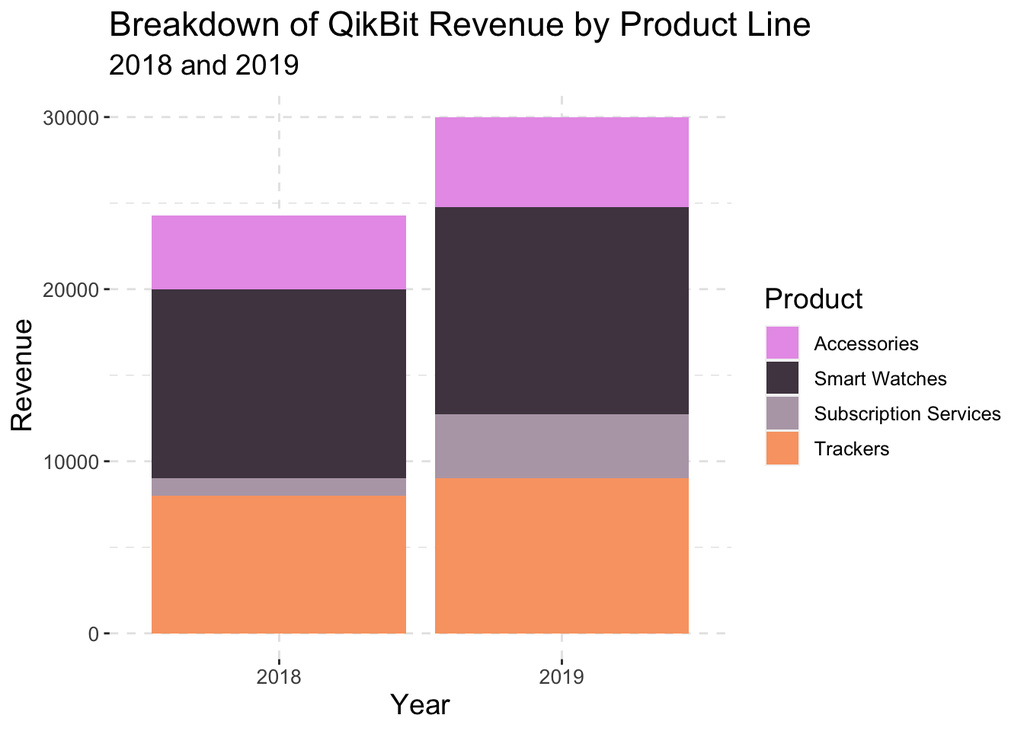

```r
ggplot(qb_revenue_breakdown) +
  aes(x = Year, y = Revenue, fill = Product) +
  geom_col() +
  scale_fill_manual(values = col_scheme) +
  ggtitle(
    "Breakdown of QikBit Revenue by Product Line",
    subtitle =  "2018 and 2019"
  ) +
  theme_qb
```

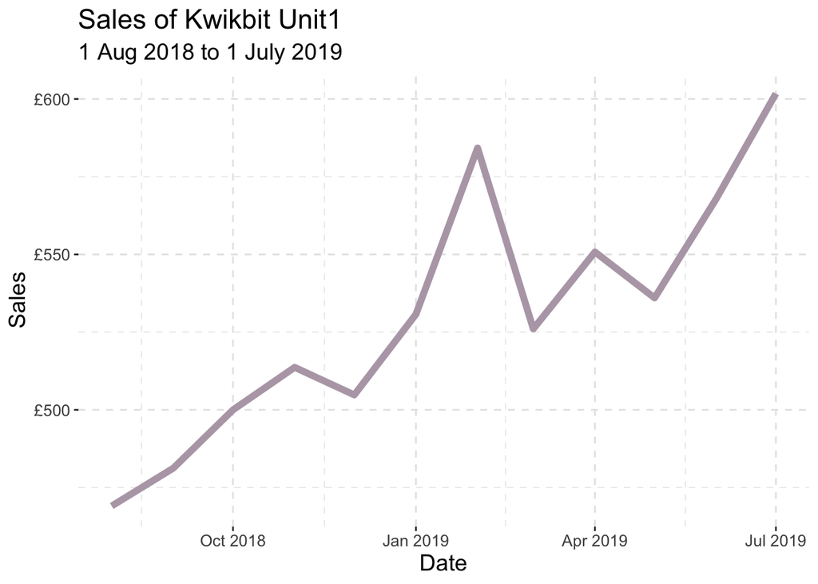

```r
kwikbit_sales <- subset(qb_monthly_sales, Cashflow == "Kwikbit Unit 1 Sales")

ggplot(kwikbit_sales) +
  aes(x = Date, y = Amount, group = Cashflow) +
  geom_line(size = 2, colour = col_scheme[3]) +
  theme_qb +
  scale_y_continuous("Sales", labels = scales::dollar_format(prefix = "£")) +
  ggtitle("Sales of Kwikbit Unit1", subtitle = "1 Aug 2018 to 1 July 2019")
```

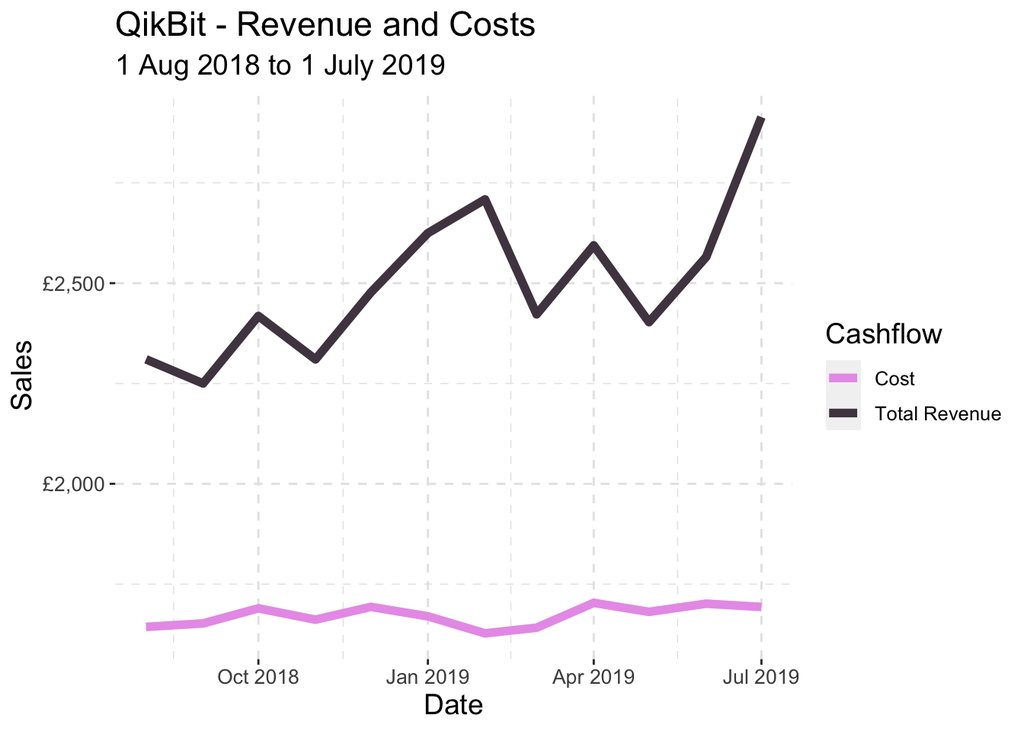

```r
revenue_and_costs <- subset(qb_monthly_sales, Cashflow != "Kwikbit Unit 1 Sales")

ggplot(revenue_and_costs) +
  aes(x = Date, y = Amount, colour = Cashflow, group = Cashflow) +
  geom_line(size = 2) +
  theme_qb +
  scale_colour_manual(values = col_scheme) +
  scale_y_continuous("Sales", labels = scales::dollar_format(prefix = "£")) +
  ggtitle("QikBit - Revenue and Costs", subtitle = "1 Aug 2018 to 1 July 2019")
```

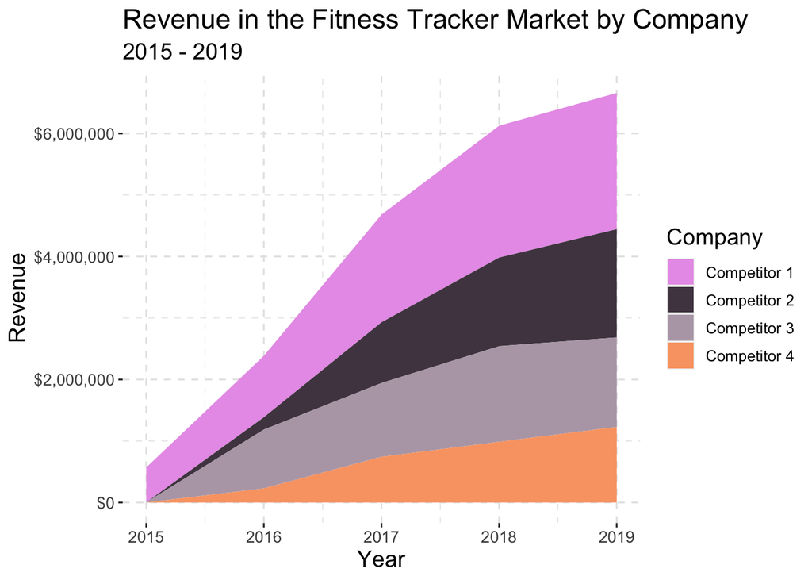

```r
ggplot(qb_competitors) +
  aes(x = Year, y = Revenue, fill = Company) +
  geom_area() +
  scale_y_continuous(labels = scales::dollar) +
  theme_qb +
  scale_fill_manual(values = col_scheme) +
  ggtitle(
    "Revenue in the Fitness Tracker Market by Company",
    subtitle = "2015 - 2019"
  )
```

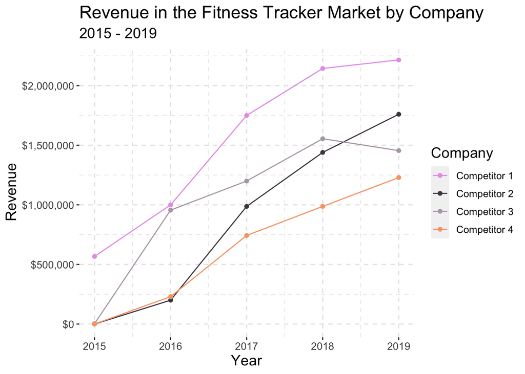

```r
ggplot(qb_competitors) +
  aes(x = Year, y = Revenue, colour = Company) +
  geom_line() +
  geom_point() +
  scale_y_continuous(labels = scales::dollar) +
  theme_qb +
  scale_colour_manual(values = col_scheme) +
  ggtitle(
    "Revenue in the Fitness Tracker Market by Company",
    subtitle = "2015 - 2019"
  )
```

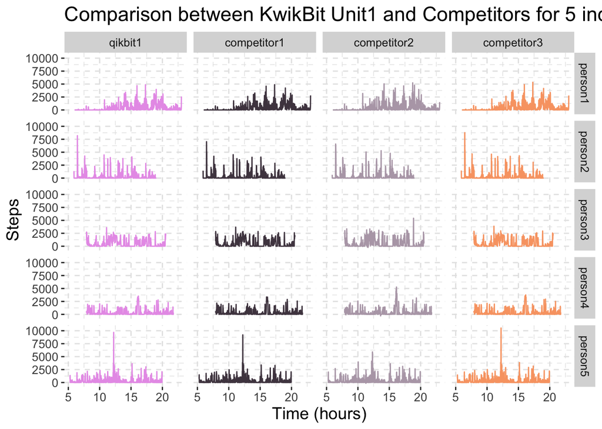

```r
ggplot(qb_device_data) +
  aes(x = decimal_hour, y = counts, colour = device) +
  geom_line(show.legend = FALSE) +
  scale_x_continuous("Time (hours)") +
  scale_y_continuous("Steps") +
  facet_grid(id ~ device) +
  scale_colour_manual(values = col_scheme) +
  theme_qb +
  ggtitle("Comparison between KwikBit Unit1 and Competitors for 5 individuals")
```

# 3 Extension

**Question 1.**  
Try out different ways of plotting these three datasets. Which graphs do you think are particularly effective at showing QikBit’s success?